# Project 3 - Dogs, Fried Chicken or Blueberry Muffins?

Group6: Sijian Xuan, Xinyao Guo, Siyi Wang, Xiaoyu Zhou, Pinren Chen

Oct 10, 2017

# Install necessary packages.

# Set the working directory to the image folder.

# Read Data

```r
sift.feature=read.csv("../data/sift_feature.csv", header = T)
lbp.feature=read.csv("../data/lbp_feature.csv", header = F)
hog.feature = read.csv("../data/hog_feature.csv")
label=read.csv("../data/trainlabel.csv")
```

# SIFT feature

#### Make dataset

```r
sift_data=data.frame(cbind(label,sift.feature[,-1]))
test.index=sample(1:3000,500,replace=F)
colnames(sift_data)[2]="y"
sift_data = sift_data[,-1]
test.sift=sift_data[test.index,]
test.x.sift=test.sift[,-1]
train.sift=sift_data[-test.index,]
```

# Baseline model: GBM + SIFT

#### Tune parameters:n.trees = 250, shrinkage = 0.1

```r
#training time is kind of long so I write it in csv and
#read it for faster in knit process
features <- train.sift
dim(features)
label_train<-train.sift
dim(label_train)
y<-label_train[,1]
X<-features[,-1]
source("../lib/tune gbm.r")
colnames(err_cv) = c("mean of cv.error","sd of cv.error")
rownames(err_cv) = c("depth = 3", "depth = 5", "depth = 7", "depth = 9","depth = 11")
write.csv(err_cv,file = "../output/err_cv_for_baseline.csv")
```

```r
err_cv_for_baseline = read.csv("../output/err_cv_for_baseline.csv")
print(err_cv_for_baseline)
```

```
##            X mean.of.cv.error sd.of.cv.error
## 1  depth = 3           0.2700     0.01542725
## 2  depth = 5           0.2552     0.02124147
## 3  depth = 7           0.2696     0.02511573
## 4  depth = 9           0.2632     0.02410809
## 5 depth = 11           0.2548     0.02100476
```

# Other models + SIFT

#### The 5000-dimensional SIFT feature takes a long time to get the results. If PCA is used to do dimension reduction, the accuracy become really low. It makes sense because doing PCA dimension reduction means losing information. As we are pursuing higher accuracy and shorter time at the same time, we started to use other feature extraction methods. With Zhilin’s suggestion, we use Local Binary Patterns(LBP), Histogram of oriented gradients(HoG) and Convolutional Neural Network(CNN) to extract features.

# Local Binary Patterns(LBP)

#### Local Binary Pattern (LBP) is a simple yet very efficient texture operator which labels the pixels of an image by thresholding the neighborhood of each pixel and considers the result as a binary number. Due to its discriminative power and computational simplicity, LBP texture operator has become a popular approach in various applications. It can be seen as a unifying approach to the traditionally divergent statistical and structural models of texture analysis. Perhaps the most important property of the LBP operator in real-world applications is its robustness to monotonic gray-scale changes caused, for example, by illumination variations. Another important property is its computational simplicity, which makes it possible to analyze images in challenging real-time settings.

#### A useful extension to the original operator is the so-called uniform pattern, which can be used to reduce the length of the feature vector and implement a simple rotation invariant descriptor. This idea is motivated by the fact that some binary patterns occur more commonly in texture images than others. A local binary pattern is called uniform if the binary pattern contains at most two 0-1 or 1-0 transitions. For example, 00010000(2 transitions) is a uniform pattern, 01010100(6 transitions) is not. In the computation of the LBP histogram, the histogram has a separate bin for every uniform pattern, and all non-uniform patterns are assigned to a single bin. Using uniform patterns, the length of the feature vector for a single cell reduces from 256 to 59. The 58 uniform binary patterns correspond to the integers 0, 1, 2, 3, 4, 6, 7, 8, 12, 14, 15, 16, 24, 28, 30, 31, 32, 48, 56, 60, 62, 63, 64, 96, 112, 120, 124, 126, 127, 128, 129, 131, 135, 143, 159, 191, 192, 193, 195, 199, 207, 223, 224, 225, 227, 231, 239, 240, 241, 243, 247, 248, 249, 251, 252, 253, 254 and 255.

#### We used MATLAB to extract LBP features(adapted codes from Zhilin’s work, I added a filter for color image and grayscale image). The column dimension is 59, which is much less than 5000. So it is reasonable that we expect a decreased time usage. The time use is 569.281s.

#### Make LBP dataset

```r
source("../lib/train.r")
source("../lib/test.r")

lbpdata = data.frame(cbind(label,lbp.feature))
colnames(lbpdata)[2] = "y"
lbpdata = lbpdata[,-1]
test.lbp = lbpdata[test.index,]
test.x.lbp = test.lbp[,-1]
train.lbp = lbpdata[-test.index,]
```

## SVM + LBP

#### Tune Parameters: cost=10, gamma=0.01

```r
svm.model <- train.svm(train.lbp)
svm.pre=test.svm(svm.model,test.x.lbp)
table(svm.pre,test.lbp$y)
```

```
##
## svm.pre   0   1   2
##       0 138  10   5
##       1  20 127  22
##       2   9  16 153
```

# Histograms of Orientation Gradients

### Algorithm Overview

#### Local shape information often well described by the distribution of intensity gradients or edge directions even without precise information about the location of the edges themselves.

#### Divide image into small sub-images: “cells” Cells can be rectangular (R-HOG) or circular (C-HOG)

#### Accumulate a histogram of edge orientations within that cell

#### The combined histogram entries are used as the feature vector describing the object

#### To provide better illumination invariance (lighting, shadows, etc.) normalize the cells across larger regions incorporating multiple cells: “blocks”

### Why HOG?

#### Capture edge or gradient structure that is very characteristic of local shape

#### Relatively invariant to local geometric and photometric transformations

###### Within cell rotations and translations do not affect the HOG values

###### Illumination invariance achieved through normalization

#### The spatial and orientation sampling densities can be tuned for different applications

###### For human detection (Dalal and Triggs) coarse spatial sampling and fine orientation sampling works best

###### For hand gesture recognition (Fernandez-Llorca and Lacey) finer spatial sampling and orientation sampling is required

#### We extracted HoG feature using R, it can be found in “./lib/hog_feature_extraction.r”.

# Some advanced models + HoG

## Note we are not using GBM anymore because it takes so long time to run.

#### Make HoG dataset

```r
hogdata = data.frame(cbind(label,hog.feature[,-1]))
colnames(hogdata)[2] = "y"
hogdata = hogdata[,-1]
test.hog = hogdata[test.index,]
test.x.hog = test.hog[,-1]
train.hog = hogdata[-test.index,]
```

# Cross Validation Error Rate

```r
#These lines also take long time to run so I just run it once and save it into a csv file and read it to save time.
source("../lib/cross_validation.R")
cv.error.lbp =cv.function(lbpdata,5)
cv.error.hog = cv.function(hogdata,5)
print (cv.error.lbp)
print(cv.error.hog)
write.csv(cv.error.lbp,"../output/cv.error.lbp.csv")
write.csv(cv.error.hog,"../output/cv.error.hog.csv")
```

```r
cv.error.lbp = read.csv("../output/cv.error.lbp.csv")
cv.error.hog = read.csv("../output/cv.error.hog.csv")
print(cv.error.lbp)
```

```
##   X        bp        rf       svm  logistic   xgboost
## 1 1 0.3506667 0.3016667 0.1956667 0.2393333 0.2453333
```

```r
print(cv.error.hog)
```

```
##   X        bp        rf       svm  logistic   xgboost
## 1 1 0.3143333 0.2546667 0.2106667 0.2203333 0.1993333
```

# Final Train & Time

```r
c=system.time(bp <- train.bp(lbpdata))
d=system.time(rf <- train.rf(lbpdata))
```

```
## mtry = 7  OOB error = 30.23%
## Searching left ...
## mtry = 5     OOB error = 29.7%
## 0.01764057 1e-05
## mtry = 4     OOB error = 30.27%
## -0.01907969 1e-05
## Searching right ...
## mtry = 10    OOB error = 29.97%
## -0.008978676 1e-05
```

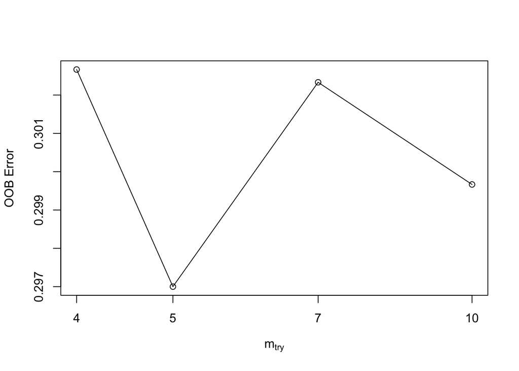

```r
e=system.time(svm <- train.svm(lbpdata))
f=system.time(logistic <- train.log(lbpdata))
g = system.time(xgboost <- train.xgboost(lbpdata))
time_lbp=list(bp=c,rf=d,svm=e,logistic=f,xgboost = g)

c=system.time(bp <- train.bp(hogdata))
d=system.time(rf <- train.rf(hogdata))
```

```
## mtry = 7  OOB error = 24.63%
## Searching left ...
## mtry = 5     OOB error = 24.6%
## 0.00135318 1e-05
## mtry = 4     OOB error = 24.87%
## -0.01084011 1e-05
## Searching right ...
## mtry = 10    OOB error = 24.17%
## 0.01761518 1e-05
## mtry = 15    OOB error = 24.3%
## -0.005517241 1e-05
```

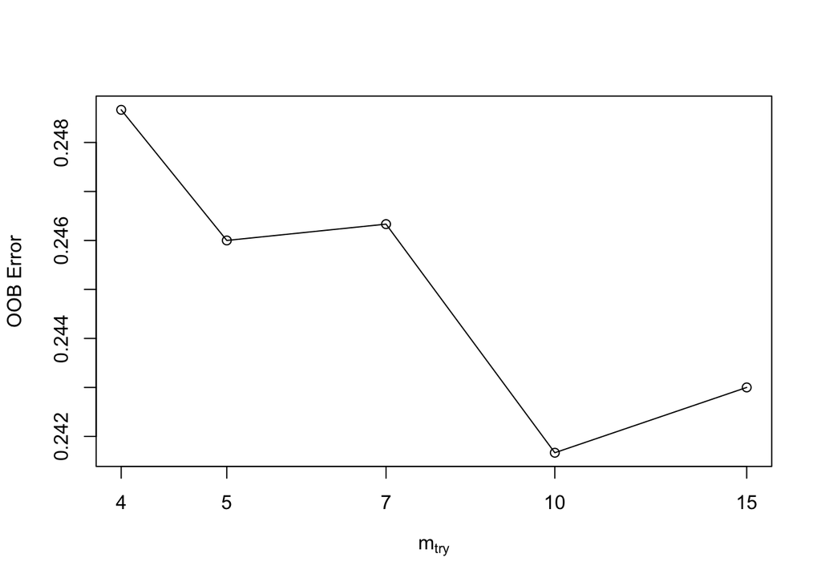

```r
e=system.time(svm <- train.svm(hogdata))
f=system.time(logistic <- train.log(hogdata))
g = system.time(xgboost <- train.xgboost(hogdata))
time_hog=list(bp=c,rf=d,svm=e,logistic=f,xgboost = g)

print(time_lbp)
```

```
## $bp
##    user  system elapsed
##   0.394   0.003   0.487
##
## $rf
##    user  system elapsed
##  50.293   0.088  50.501
##
## $svm
##    user  system elapsed
##   1.744   0.013   1.757
##
## $logistic
##    user  system elapsed
##   0.301   0.003   0.317
##
## $xgboost
##    user  system elapsed
##  27.201   0.015  27.222
```

```r
print(time_hog)
```

```
## $bp
##    user  system elapsed
##   0.255   0.000   0.255
##
## $rf
##    user  system elapsed
##  53.395   0.089  53.496
##
## $svm
##    user  system elapsed
##   1.493   0.012   1.505
##
## $logistic
##    user  system elapsed
##   0.270   0.003   0.273
##
## $xgboost
##    user  system elapsed
##  21.353   0.009  21.367
```

# CNN model for image classfication:

## step 1: install theano and lagsgne

#### $pip install -r https://raw.githubusercontent.com/Lasagne/Lasagne/v0.1/requirements.txt *-install theano 0.7*

## step 2: train the neural net work( environment: python 2.7)

### $python CNN_build.py [directory for training_set folder]

#### The [directory for training_set folder] should be folder training_set’s local path e.g. “C:/Users/zjutc/Desktop”.

#### The training_set folder should include:

#### images- a folder including all image files for training

#### label_train.csv- a csv file including labels for all images

#### The output is the result of every epoch and a CNNmodel.pkl file is saved in training_set folder. This file stores the weights for CNN.

#### our .pkl model and training report are saved in output folder

## step 3: use the CNN model we get for validation:

### $python CNN_predict.py [directory for test_set folder] [model_path]

#### [directory for test_set folder] should be folder test_set’s local path e.g. “C:/Users/zjutc/Desktop”

#### [model_path] should be local path for pkl file e.g.“C:/Users/zjutc/Desktop/training_set/CNNmodel.pkl”

#### The output is label predicted by CNN model. It is saved in test_set and named as “label_CNN.csv”

#### Also the error rate would be printed.

#### We use 2500 images for training and the rest for validation. The accuracy can achieve 90%. But it can take 25 minutes for validating 500 images. So we don’t choose it for our final model.

# Final Model

#### We choose SVM + LBP as our final mdoel since it has high accuracy as well as short time usage.